# Γραμμική παλινδρόμηση στην R

Κατά την μελέτη της αλληλεξάρτησης δύο μεταβλητών Χ και Υ παρατηρήθηκαν τα παρακάτω ζεύγη τιμών.

```r
df <- data.frame(x=c(0,1,2,3,4),
                  y=c(1,3,7,12,17))
df
```

| x | y |
| --- | --- |
| 0 | 1 |
| 1 | 3 |
| 2 | 7 |
| 3 | 12 |
| 4 | 17 |

```r
n=nrow(df)
```

Ας εκτυπώσουμε τα δεδομένα που προαναφέρθηκαν σε διάγραμμα διασποράς (scatterplot):

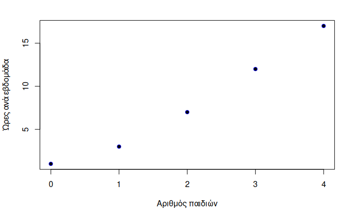

```r
plot(df$x,df$y,  col='blue', pch=21, bg="black", xlab="Αριθμός παιδιών", ylab="Ώρες ανά εβδομάδα")
```

Εκτέλεση της γραμμικής παλινδρόμησης:

```r
model <- lm(formula = y ~ x, data=df)
```

Μέσω της απλής εκτύπωσης του μοντέλου μπορούμε να λάβουμε ελάχιστες πληροφορίες για αυτό

```r
model
```

```
Call:
lm(formula = y ~ x, data = df)

Coefficients:
(Intercept)            x
       -0.2          4.1
```

Οι εκτιμήτριες της ευθείας παλινδρόμησης ελαχίστων τετραγώνων λαμβάνονται ξεχωριστά ως εξής

```r
b=model$coefficients["x"]
a=model$coefficients["(Intercept)"]

print(sprintf("Η τιμή της παραμέτρου β είναι: %s και της παραμέτρου α είναι: %s", as.vector(b),round(as.vector(a),2)))
```

```
[1] "Η τιμή της παραμέτρου β είναι: 4.1 και της παραμέτρου α είναι: -0.2"
```

Για να πάρουμε περισσότερες πληροφορίες για ένα μοντέλο τρέχουμε την εντολή summary η οποία δέχεται ως όρισμα το μοντέλο.

```r
summary(model)
```

```
Call:
lm(formula = y ~ x, data = df)

Residuals:
   1    2    3    4    5
 1.2 -0.9 -1.0 -0.1  0.8

Coefficients:
            Estimate Std. Error t value Pr(>|t|)
(Intercept)  -0.2000     0.8832  -0.226  0.83540
x             4.1000     0.3606  11.371  0.00146 **
---
Signif. codes:  0 ‘***’ 0.001 ‘**’ 0.01 ‘*’ 0.05 ‘.’ 0.1 ‘ ’ 1

Residual standard error: 1.14 on 3 degrees of freedom
Multiple R-squared:  0.9773,    Adjusted R-squared:  0.9698
F-statistic: 129.3 on 1 and 3 DF,  p-value: 0.001459
```

Ας δούμε ποιες τιμές έχουν εκτιμηθεί με βάση το μοντέλο

```r
predict(model)
```

```
   1    2    3    4    5
-0.2  3.9  8.0 12.1 16.2
```

Προβολή διαγράμματος κατάλοιπων

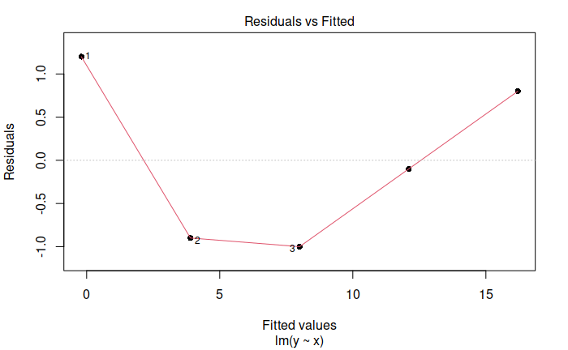

```r
plot(model, pch=16, which=1)
```

Μπορούμε να υπολογίσουμε το μέσο τετραγωνικό σφάλμα (με βάση τον σχετικό τύπο):

```r
sum((df$y - predict(model))^2)/n
```

```
[1] 0.78
```

Ή εναλλακτικά με την συνάρτηση mse() από την βιβλιοθήκη Metrics (απαιτείται εγκατάσταση).

```r
library(Metrics)
mse(df$y, predict(model))
```

```
[1] 0.78
```

To μέσο τετραγωνικό σφάλμα είναι μη συγκρίσιμο μέγεθος και δίνεται σε τετραγωνικές μονάδες μέτρησης της μεταβλητής y.

Ο δείκτης προσδιορισμού αποτυπώνει καλύτερα την σχέση των δύο μεταβλητών και την ερμηνεία της μεταβλητικότητας της Y από την σχέση της με την Χ. Ο δείκτης προσδιορισμού ρ2 έχει υπολογιστεί ήδη στην R και για να τον εξάγουμε από το μοντέλο τρέχουμε:

```r
summary(model)$r.squared
```

```
[1] 0.9773256
```

Το παραπάνω σημαίνει ότι σχεδόν το 98% της μεταβλητικότητας της Υ ερμηνεύεται από την επίδραση από την σχέση της με την Χ. Το υπόλοιπο 2% της μεταβλητικότητας της Υ εξαρτάται από άλλους παράγοντες.

Προβολή της ευθείας ελαχίστων τετραγώνων στο διάγραμμα διασποράς:

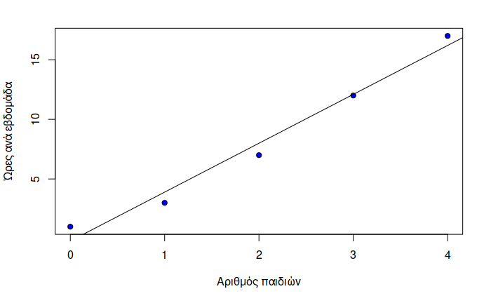

```r
plot(df$x,df$y,  col='black', pch=21, bg="blue", xlab="Αριθμός παιδιών", ylab="Ώρες ανά εβδομάδα")

abline(model)
```

Ερμηνεία της ευθείας γραμμικής παλινδρόμησης y=a+bx.

Όπως είδαμε ο συντελεστής παλινδρόμησης είναι σχεδόν 4,1. Αυτό σημαίνει ότι για κάθε πρόσθετη μονάδα Χ αυξάνεται κατά 4,1 μονάδες η Υ. Ο συντελεστής α δηλαδή εκεί που τέμνει η ευθεία τον άξονα y δηλαδή για x=0 τότε y=-0,2 ώρες.

Υπολογισμός του συντελεστή συσχέτισης Pearson

```r
cor(df$x, df$y, method="pearson")
```

```
[1] 0.9885978
```

Υπάρχει ισχυρή θετική συσχέτιση ανάμεσα στις δύο μεταβλητές. Όπως αναφέρθηκε συσχέτιση δεν σημαίνει απαραίτητα και αιτιότητα.